# Compte rendu - TP1 Initiation à R

Laroussi Labid Bachri

21-09-2025

# 1.Introduction

## Premiers pas avec R et RMarkdown

Ce TP a pour but d’initiation au logiciel Rstudio et au language de programmation R dans le cadre de l’UE TDB.

## 1.1 Utilisation de variables

Les variables (ou objets) permettent de stocker des données qui peuvent être :

- une valeur simple de type numérique (`numeric`), logique (`logical`), chaîne de caractères (`character`) ou qualitative (`factor`).
- une liste (appelée `vector`).
- un tableau à 2 dimensions, les colonnes pouvant avoir des types différents (`data.frame`). Ce sont les plus utilisés en statistiques.
- un tableau à 2 dimensions, toutes les cases ayant le même type (`matrix`).
- un tableau à plus de 2 dimension (`array`).
- une combinaison des précédents (`list`).

Une variable a un nom (défini par l’utilisateur) qui permet d’accéder à son contenu.

**Créer une variable appelée x qui stocke le résultat du calcul précédent 1 + 2 + 3.** L’affectation d’une valeur à une variable se fait avec <- ou le signe = comme suit dans la console :

L’argument include=TRUE affiche le code dans le rendu HTML et le resultat également.

```r
x <- 1 + 2 + 3
texte <- "j'aime bien R"
logique <- TRUE
```

## 1.2 Vecteurs

```r
x <- c(2, 3, 5, 8, 4, 6)
longueur <- length(x)

# Manipulation des elements du vecteur
deuxieme_element <- x[2]
deuxieme_element
```

```
## [1] 3
```

```r
changer_element <- x[2] <- 7 # on peut changer des elements
x
```

```
## [1] 2 7 5 8 4 6
```

```r
ajouter_element <- x[7] <- 12 # Ajouter des elements
x
```

```
## [1]  2  7  5  8  4  6 12
```

```r
retirer_element <- x <- x[-1] # mais aussi retirer des elements!
x
```

```
## [1]  7  5  8  4  6 12
```

```r
acces_plusiuers_elements <- x[c(2, 4, 1)]
acces_plusiuers_elements
```

```
## [1] 5 4 7
```

```r
valeurs_2_a_4 <- x[2:4]
valeurs_2_a_4
```

```
## [1] 5 8 4
```

```r
# Valeurs superieures a 4
valeurs_superieures_a_4 <- x[x > 4]
valeurs_superieures_a_4
```

```
## [1]  7  5  8  6 12
```

```r
# Inverse du vecteur
inverse_de_x <- 1 / x
inverse_de_x
```

```
## [1] 0.14285714 0.20000000 0.12500000 0.25000000 0.16666667 0.08333333
```

```r
# Double du vecteur
double_de_x <- 2 * x
double_de_x
```

```
## [1] 14 10 16  8 12 24
```

```r
# Utilisation de fonction round()
arrondir_x_divise_par4 <- round(x / 4)
arrondir_x_divise_par4
```

```
## [1] 2 1 2 1 2 3
```

```r
arrondir_2_x_divise_par4 <- round(x / 4, 2) # on ajoute ici l'argument qui permet de choisir combien de chiffres apres la virgule
arrondir_2_x_divise_par4
```

```
## [1] 1.75 1.25 2.00 1.00 1.50 3.00
```

## 1.3 Fonctions

## Statistiques descriptives.

```r
# On peut calculer les stastistiques descriptives
summary(x)
```

```
##    Min. 1st Qu.  Median    Mean 3rd Qu.    Max.
##    4.00    5.25    6.50    7.00    7.75   12.00
```

```r
valeur_min <- min(x)
valeur_min
```

```
## [1] 4
```

```r
valeur_max <- max(x)
valeur_max
```

```
## [1] 12
```

```r
mediane <- median(x)
mediane
```

```
## [1] 6.5
```

```r
moyenne <- mean(x)
moyenne
```

```
## [1] 7
```

```r
variance <- var(x)
variance
```

```
## [1] 8
```

```r
ecart_type <- sd(x)
ecart_type
```

```
## [1] 2.828427
```

# 2.Importation des données.

## Lecture et écriture de fichiers contenant des données.

Il existe plusieurs façons de selectionner un fichier

Option 1 : on peut utiliser la fonction **file = file.choose()** pour selectionner manuellement le fichier.

**fichier = readline(prompt = “Entrez le chemin complet du fichier : (astuce : la commande **realpath**, propre aux systèmes **Unix/Linux**, donne le chemin absolu d’un fichier)”)**

Option 2 : # On peut aussi utiliser cette notation pour saisir directement le chemin absolue du fichier ( peut etre plus utile et adapte pour des automatisations par exemple pour éviter de devoir selectionner manuellement avec la souris plusieurs fichiers) Sous R la fonction x = input(“Entrez le chemin du fichier :”) ne marche pas.

Nous allons le saisir directement dans les params YAML pour le recuperer ici, car lors du Knit vers HTML, on ne peut pas interagir avec RMarkdown. Cette option marche si on execute le script R dans la console.

```r
fichier <- params$fichier_path
croissance <- read.table(fichier,
  sep = params$separateur, # le separateur qui va etre utilisé est la tabulation mais celui ci peut varier ("\n" , ";" , "," etc)
  header = T, # Afficher premiere ligne = noms des colonnes
  stringsAsFactors = T
) # Interpreter les strings comme Factors ici le poids, taille ou l'origine. Les variables peuvent être qualitative ( origine_geo ) ou quantitatives ( Poids , taille).
```

```
## [1] "poids"       "taille"      "origine_geo"
```

```
## 5 premieres lignes
```

```
##   poids taille origine_geo
## 1 383.5   44.4         pyr
## 2 395.8   50.7         pyr
## 3 406.8   53.5         pyr
## 4 387.7   54.1         pyr
## 5 407.6   54.3         pyr
```

```
## Structure du jeu de données :
```

```
## 'data.frame':    100 obs. of  3 variables:
##  $ poids      : num  384 396 407 388 408 ...
##  $ taille     : num  44.4 50.7 53.5 54.1 54.3 54.9 54.9 55.1 55.4 55.4 ...
##  $ origine_geo: Factor w/ 12 levels "alpes","amsterd",..: 10 10 10 10 10 10 10 10 10 10 ...
```

# 2.1 Manipulation de nos données

## Statistiques descriptives

```r
# On peut  utiliser cat() comme parse()
taille_moyenne_plantes <- mean(croissance$taille)
cat("La taille moyenne des plantes est de", taille_moyenne_plantes, "centimètres")
```

```
## La taille moyenne des plantes est de 66.967 centimètres
```

```r
poids_moyen_plantes <- mean(croissance$poids)
cat("Le poids moyen des plantes est de", poids_moyen_plantes, "grammes")
```

```
## Le poids moyen des plantes est de 419.509 grammes
```

```
## Le variance des plantes est de 78.64
```

[output not shown]

## Autres manipulations

```r
variables <- names(croissance)
croissance$poids
```

```
##   [1] 383.5 395.8 406.8 387.7 407.6 387.6 393.3 402.4 392.9 396.5 383.2 407.7
##  [13] 402.6 422.1 402.9 403.1 390.2 417.3 396.9 398.4 403.3 410.4 389.6 398.3
##  [25] 389.6 400.3 402.9 417.5 392.8 415.4 412.7 420.8 412.0 403.1 421.8 423.2
##  [37] 421.8 418.5 436.8 420.7 414.2 415.5 436.1 412.5 423.3 431.9 431.6 403.4
##  [49] 421.1 420.2 413.6 433.5 413.5 404.8 431.0 422.3 424.1 418.4 437.7 442.0
##  [61] 422.1 421.3 410.2 433.8 431.5 426.2 429.9 427.8 425.6 430.0 415.4 427.1
##  [73] 422.5 422.5 416.1 429.1 437.4 453.7 434.8 437.1 441.5 416.4 432.5 440.7
##  [85] 424.3 435.1 440.8 446.9 420.7 415.6 446.5 436.6 443.8 415.4 446.9 442.7
##  [97] 449.6 457.3 459.1 443.7
```

```r
attach(croissance)
poids # On peut faire attach pour éviter d'écrire croisssance$… à chaque fois.
```

```
##   [1] 383.5 395.8 406.8 387.7 407.6 387.6 393.3 402.4 392.9 396.5 383.2 407.7
##  [13] 402.6 422.1 402.9 403.1 390.2 417.3 396.9 398.4 403.3 410.4 389.6 398.3
##  [25] 389.6 400.3 402.9 417.5 392.8 415.4 412.7 420.8 412.0 403.1 421.8 423.2
##  [37] 421.8 418.5 436.8 420.7 414.2 415.5 436.1 412.5 423.3 431.9 431.6 403.4
##  [49] 421.1 420.2 413.6 433.5 413.5 404.8 431.0 422.3 424.1 418.4 437.7 442.0
##  [61] 422.1 421.3 410.2 433.8 431.5 426.2 429.9 427.8 425.6 430.0 415.4 427.1
##  [73] 422.5 422.5 416.1 429.1 437.4 453.7 434.8 437.1 441.5 416.4 432.5 440.7
##  [85] 424.3 435.1 440.8 446.9 420.7 415.6 446.5 436.6 443.8 415.4 446.9 442.7
##  [97] 449.6 457.3 459.1 443.7
```

```r
is_it_from_pyr <- origine_geo == "pyr"
is_it_from_pyr
```

```
##   [1]  TRUE  TRUE  TRUE  TRUE  TRUE  TRUE  TRUE  TRUE  TRUE  TRUE  TRUE  TRUE
##  [13]  TRUE  TRUE  TRUE  TRUE FALSE FALSE FALSE FALSE FALSE FALSE FALSE FALSE
##  [25] FALSE FALSE FALSE FALSE FALSE FALSE FALSE FALSE FALSE FALSE FALSE FALSE
##  [37] FALSE FALSE FALSE FALSE FALSE FALSE FALSE FALSE FALSE FALSE FALSE FALSE
##  [49] FALSE FALSE FALSE FALSE FALSE FALSE FALSE FALSE FALSE FALSE FALSE FALSE
##  [61] FALSE FALSE FALSE FALSE FALSE FALSE FALSE FALSE FALSE FALSE FALSE FALSE
##  [73] FALSE FALSE FALSE FALSE FALSE FALSE FALSE FALSE FALSE FALSE FALSE FALSE
##  [85] FALSE FALSE FALSE FALSE FALSE FALSE FALSE FALSE FALSE FALSE FALSE FALSE
##  [97] FALSE FALSE FALSE FALSE
```

```r
plantes_pyr <- which(origine_geo == "pyr") # identifier quels arbres ont pour originegeo et donc qui ont origine_geo == 'pyr' -> TRUE
plantes_pyr
```

```
##  [1]  1  2  3  4  5  6  7  8  9 10 11 12 13 14 15 16
```

## Quel est la taille moyenne des plantes provenant de Norwich?

```r
plantes_norwich <- (croissance$origine_geo == "norwich")

moyenne_plantes_norwich <- mean(round(croissance$taille[plantes_norwich], 2))
cat("La taille moyenne des plantes de Norwich est de", moyenne_plantes_norwich)
```

```
## La taille moyenne des plantes de Norwich est de 81.22857
```

```r
# Quel est l'écart type des plantes provenant de Norwich?
sd_norwich <- sd(plantes_norwich)

# On peut utiliser la fonction paste() pour améliorer la lisibilité.
paste("L'ecart-type des plantes de Norwich est de", round(sd_norwich, 2))
```

[output not shown]

La fonction **paste()** sert a concatener des variables avec des strings. (ou autre)

```r
pyr <- croissance[origine_geo == "pyr", 1:2]
pyr
```

```
##    poids taille
## 1  383.5   44.4
## 2  395.8   50.7
## 3  406.8   53.5
## 4  387.7   54.1
## 5  407.6   54.3
## 6  387.6   54.9
## 7  393.3   54.9
## 8  402.4   55.1
## 9  392.9   55.4
## 10 396.5   55.4
## 11 383.2   55.8
## 12 407.7   55.8
## 13 402.6   56.0
## 14 422.1   56.6
## 15 402.9   57.5
## 16 403.1   58.5
```

```r
# Quel est la valeur de poids maximal et minimal des plantes Toulousaines et Espagnoles ?

tls_esp <- croissance[origine_geo == "toulouse" | origine_geo == "espagne", 1:2]
```

L’utilisation de pipe comme operateur. (comparable à l’operateur OR)

```r
poids_max_plantes_tls_esp <- max(tls_esp$poids)
paste("Le poids maximal des plantes qui proviennent soit de Toulouse soit d'espagne est :", poids_max_plantes_tls_esp, "grammes")
```

```
## [1] "Le poids maximal des plantes qui proviennent soit de Toulouse soit d'espagne est : 436.8 grammes"
```

```r
poids_min_plantes_tls_esp <- min(tls_esp$poids)
paste("Le poids minimal des plantes qui proviennent soit de Toulouse soit d'espagne est :", poids_min_plantes_tls_esp, "grammes")
```

```
## [1] "Le poids minimal des plantes qui proviennent soit de Toulouse soit d'espagne est : 392.8 grammes"
```

```r
# On va sauvegarder ces données dans un autre fichier .txt
write.table(tls_esp, "croissance_plantes_tls_esp.txt", quote = F, col.names = T, row.names = F, sep = params$separateur)
```

## 2.1 Fonctions graphiques

Nous allons maintenant répresenter les données sous forme graphique pour mieux visulaiser les données.

```r
resume_origine_geo <- summary(origine_geo) # on synthetise les origines des plantes et compter combien de plantes ont tel origine.
camembert_origine <- function() {
  pie(resume_origine_geo,
    main = "Origine géographique des plantes", # Titre de la figure
    col = rainbow(12)
  )
} # Ajout d'autant de couleurs que des origines avec la fonction rainbow()
```

On peut écrire notre propre **fonction** pour appeler notre pie(…) et pas faire de “copier-coller”

```r
png("/Users/bachri/Documents/M1_BBS/S7/tdb/tp_tdb/figure_tp1/camembert_origine.png")
camembert_origine()
dev.off()
```

```r
file.exists("/Users/bachri/Documents/M1_BBS/S7/tdb/tp_tdb/figure_tp1/camembert_origine.png") # On peut verifier si notre fichier existe.
```

```
## [1] TRUE
```

On peut verifier si notre fichier a bien été exporté. Cette option peut etres très utile lors de l’automatisation de l’exportation de nos fichier png (camembert , boxplots, etc ) sans avoir a verifier visuellement un par un dans le dossier. Cette fonction renvoie une valeur logique “TRUE” ou “FALSE

```r
barplot_origine_geo <- function() {
  barplot(resume_origine_geo,
    main = "Origine géographique des plantes",
    col = rainbow(12)
  )
}

dir.create("/Users/bachri/Documents/M1_BBS/S7/tdb/tp_tdb/figure_tp1/", recursive = TRUE)
```

Cette fonction va nous permettre de créer un dossier meme s’il existe pas sur le working directory. L’option recursive permet de créer les dossiers parents ( ceux qui sont avant ) même s’ils n’ont pas encore été crées. Exemple ” /Users/etudiant/Desktop/TP_TDB/figures_tp1 ”

Avec l’option recursive = TRUE , le dossier figure_tp1 va être crée mais egalement le dossier TP_TDB même s’il existe pas.

```r
jpeg("/Users/bachri/Documents/M1_BBS/S7/tdb/tp_tdb/figure_tp1/Barplot_origine_geo.jpeg")
barplot_origine_geo()
dev.off()
```

```r
file.exists("/Users/bachri/Documents/M1_BBS/S7/tdb/tp_tdb/figure_tp1/Barplot_origine_geo.jpeg")
```

```
## [1] TRUE
```

```r
# On est sur une variable qualitative, on ne va parler de histogramme mais de diagramme en barres.
```

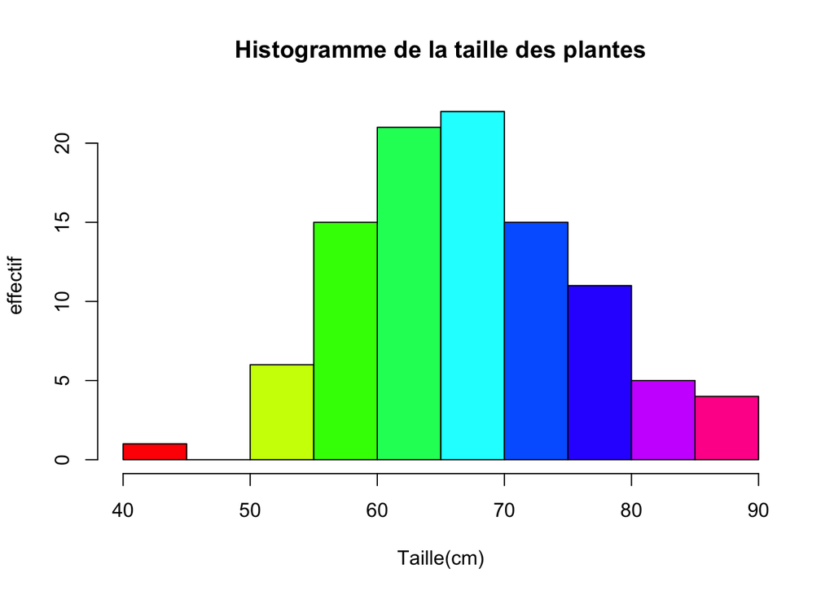

```r
# Histogrammes (variable quantitative)

hist(taille, xlim = c(40, 90), xlab = "Taille(cm)", ylab = "effectif", freq = T, main = "Histogramme de la taille des plantes", col = rainbow(10))
```

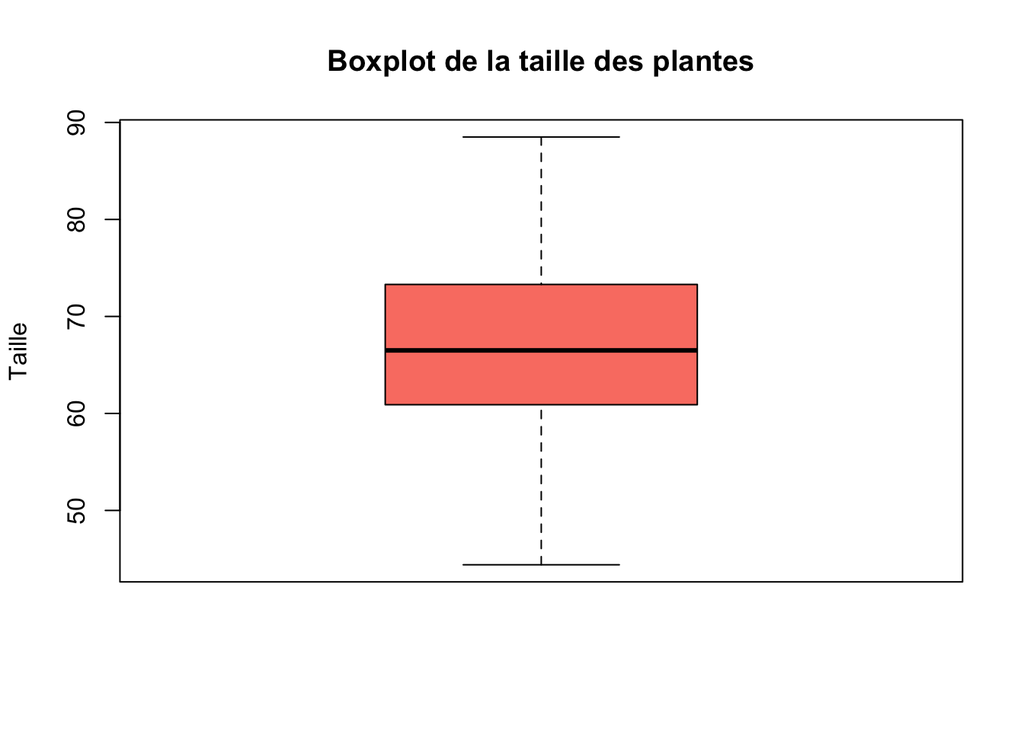

```r
# xlim=c(x,y) sert a limiter les valuers affichées sur l'histogramme.

# Boite à moustaches (variable quantitative)
boxplot(taille, main = "Boxplot de la taille des plantes", ylab = "Taille", col = "salmon")
```

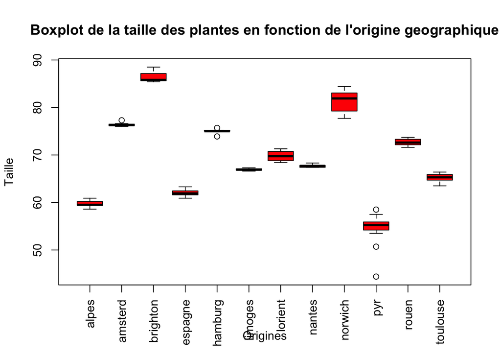

```r
# Plusieurs boite à moustaches ( une variable quantitative en fonction des modalité d'une variable qualitative )

plot(origine_geo, taille, las = 3, main = "Boxplot de la taille des plantes en fonction de l'origine geographique", col = "red", ylab = "Taille", xlab = "Origines", notch = F)
```

Les boxplots montrent que certaines origines géographiques présentent une variabilité faible (boîtes très resserrées), alors que d’autres sont plus dispersées. L’ajout de l’option (notch=TRUE) nous permet d’avoir une indication sur la comparaison des médianes. Cela va faire apparaitre des encoches qui representent l’intervalle de confiance 95%. Si les encoches ne se chevauchent pas, ( *se chevaucher : se recouvrent verticalement* ) cela suggère des différences de médiane entre groupes. Il faut savoir que cette intérpretation est approximatice et n’équivaut pas a un test statistique. Ici, il n’est pas pertinent d’utiliser notch car R renvoie : **Warning: some notches went outside hinges (‘box’): maybe set notch=FALSE** Le calcul de l’intervalle de confiance de certains notch dépasse les “hinges” ( 1er et 3eme quartile )

```
## Warning in (function (z, notch = FALSE, width = NULL, varwidth = FALSE, : some
## notches went outside hinges ('box'): maybe set notch=FALSE
```

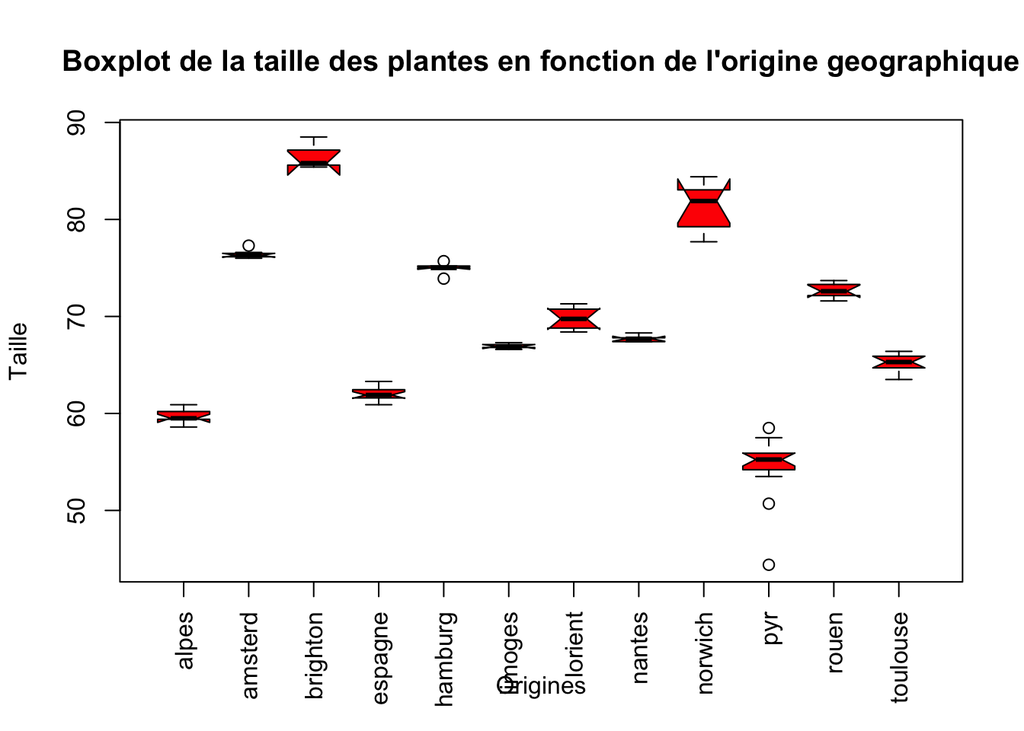

```r
plot(origine_geo, taille, las = 3, main = "Boxplot de la taille des plantes en fonction de l'origine geographique", col = "red", ylab = "Taille", xlab = "Origines", notch = T)
```

Ici, on a le message d’erreur mais on peut observer que les notches dépassent les quartiles sur certains plantes.

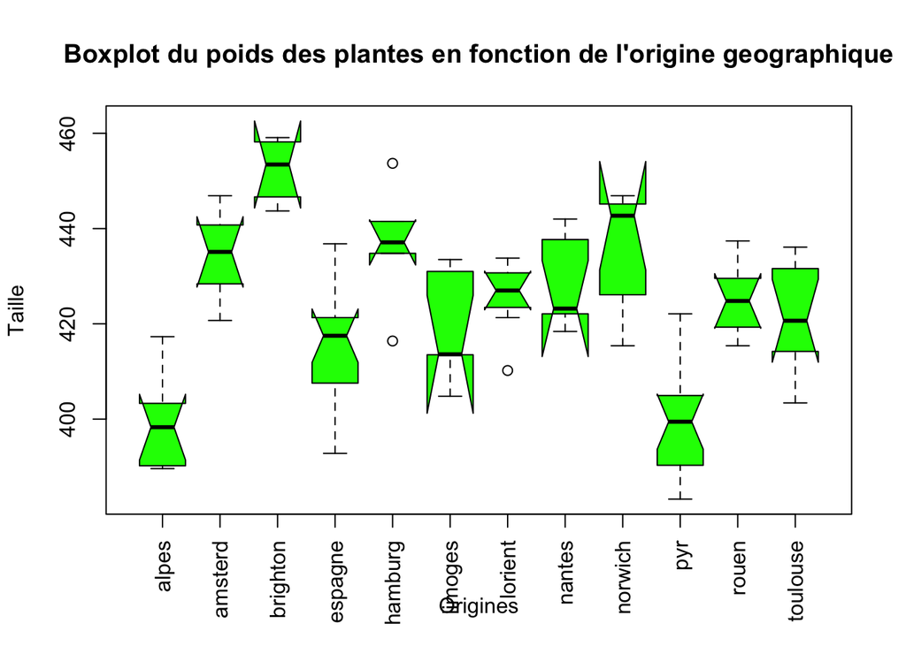

```r
plot(origine_geo, poids, las = 3, main = "Boxplot du poids des plantes en fonction de l'origine geographique", col = "green", ylab = "Taille", xlab = "Origines", notch = T)
```

Dans le cas de la variable poids, sur certains boxplot le notch est bien representé.

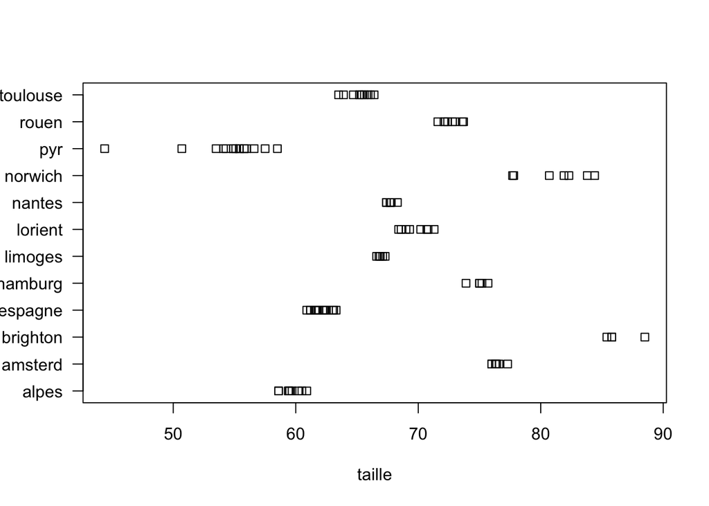

```r
stripchart(taille ~ origine_geo, las = 1)
```

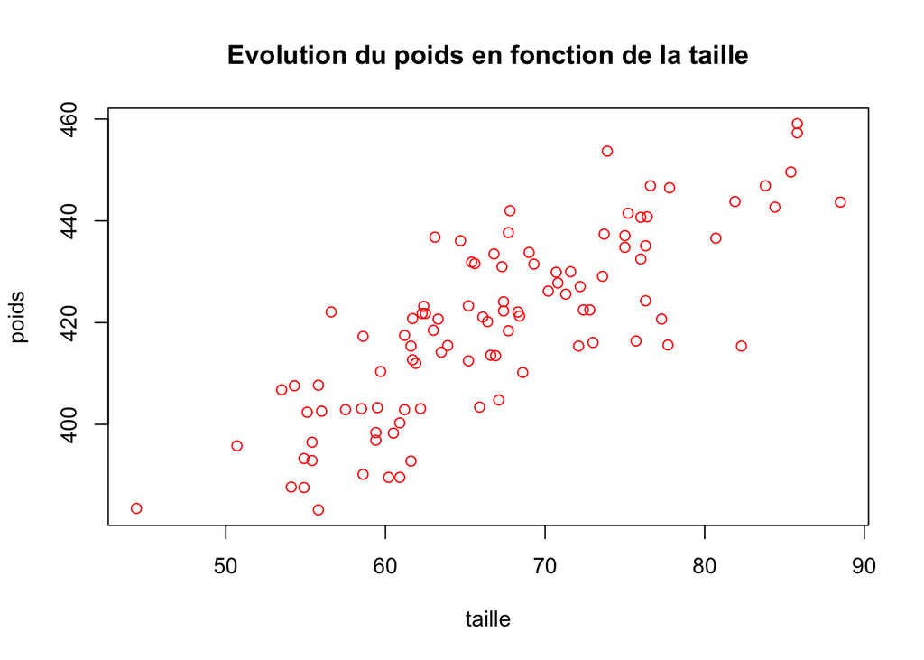

```r
plot(taille, poids, col = "red", main = "Evolution du poids en fonction de la taille")
```

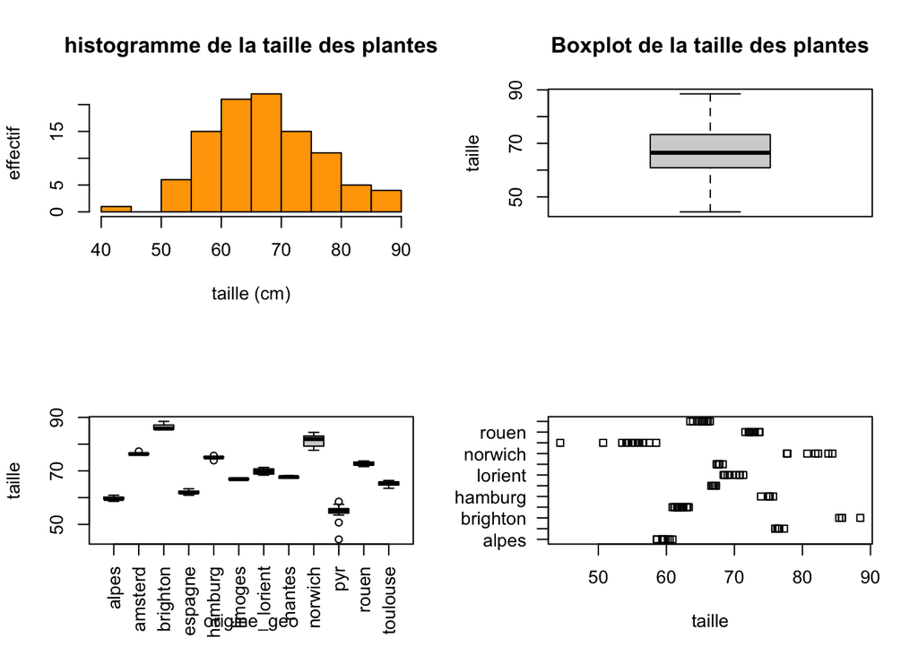

```r
# Affichage de plusieurs graphiques dans la meme fenetre
par(mfrow = c(2, 2)) # 2 en lignes et 2 en colonnes par exemple
hist(taille, xlim = c(40, 90), xlab = "taille (cm)", ylab = "effectif", freq = T, main = "histogramme de la taille des plantes", col = "orange")
# xlim=c(x,y) sert a limiter les valuers affichées sur l'histogramme.
boxplot(taille, main = "Boxplot de la taille des plantes", ylab = "taille")
plot(taille ~ origine_geo, las = 3)
stripchart(taille ~ origine_geo, las = 1)
```

```r
# detach(croissance). Important a utiliser lorsqu'on utilise attach pour travailler par exemple sur un autre jeu de données sans les mélanger.
```

## Fin du compte rendu. TDB TP1 M1

## Sources utiles:

- https://r-coder.com/system-date-time-r/ (Date)
- https://rpubs.com/ranydc/rmarkdown_themes (themes)
- https://www.rdocumentation.org/packages/base/versions/3.6.2/topics/cat (cat)
- https://www.rdocumentation.org/packages/base/versions/3.6.2/topics/paste (paste)
- https://www.statology.org/r-which-multiple-conditions/ (utilisation de pipe `|` comme opérateur OR)
- https://juba.github.io/tidyverse/14-fonctions.html (écrire ses propres fonctions)
- https://larmarange.github.io/analyse-R/export-de-graphiques.html (exportation)
- https://www.rdocumentation.org/packages/base/versions/3.6.2/topics/files2 (directories, créer des dossiers)